# examples_0402

In Adams, Massachusetts, 4 candidates (W through Z) are running in an election with a single winner. There are 7 voters (A through G) who each rank the candidates from 1 to 4, with 1 meaning first choice and 4 meaning last choice. Those rankings are shown below. Each column represents a single voter's ranking.

|  | A | B | C | D | E | F | G |
| --- | --- | --- | --- | --- | --- | --- | --- |
| candidate W | 2 | 4 | 1 | 3 | 2 | 1 | 3 |
| candidate X | 4 | 1 | 2 | 2 | 3 | 2 | 1 |
| candidate Y | 3 | 3 | 3 | 4 | 1 | 3 | 2 |
| candidate Z | 1 | 2 | 4 | 1 | 4 | 4 | 4 |

A [Condorcet winner](https://en.wikipedia.org/wiki/Condorcet_method) would win in a head-to-head election against any other candidate. Who is the Condorcet winner? (Or, possibly, there is none.)

WXYZNo Condorcet winner!

Consider every head-to-head election. With 4 candidates, there will be ${4\choose 2 }= 6$ pairings (see [combinations](https://en.wikipedia.org/wiki/Binomial_coefficient)).

Compare candidates W and X.

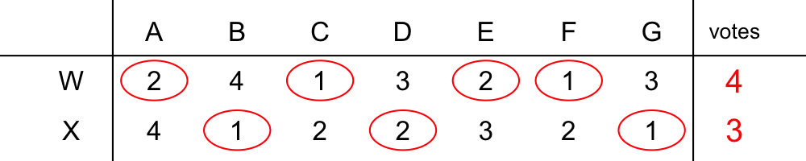

So, W beats X.

Compare candidates W and Y.

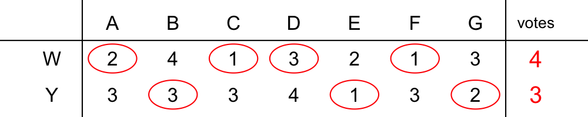

So, W beats Y.

Compare candidates W and Z.

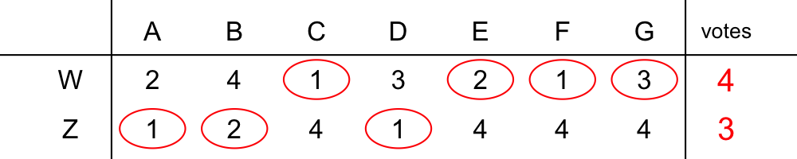

So, W beats Z.

Compare candidates X and Y.

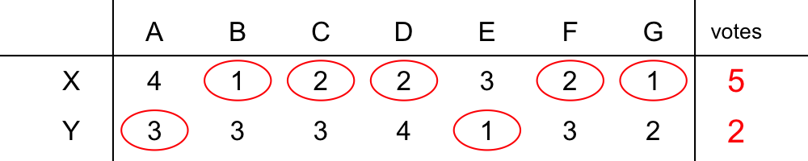

So, X beats Y.

Compare candidates X and Z.

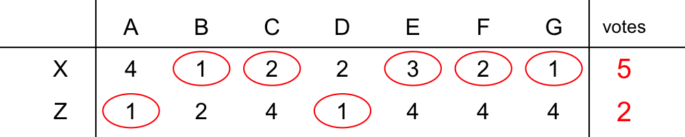

So, X beats Z.

Compare candidates Y and Z.

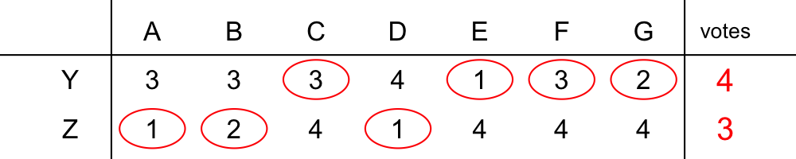

So, Y beats Z.

Organize all this into a winner table.

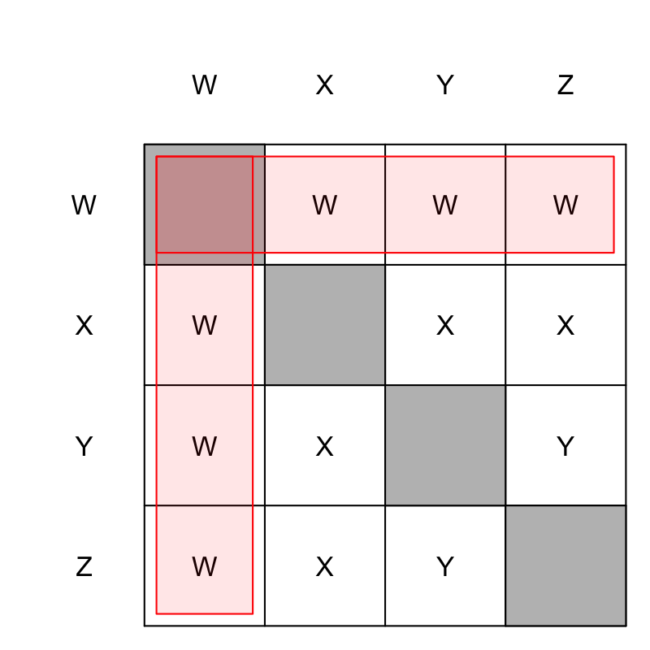

Notice W wins against all other candidates. Thus W is the Condorcet winner.

In Adams, Massachusetts, 4 candidates (W through Z) are running in an election with a single winner. There are 7 voters (A through G) who each rank the candidates from 1 to 4, with 1 meaning first choice and 4 meaning last choice. Those rankings are shown below. Each column represents a single voter's ranking.

|  | A | B | C | D | E | F | G |
| --- | --- | --- | --- | --- | --- | --- | --- |
| candidate W | 2 | 4 | 2 | 4 | 3 | 3 | 3 |
| candidate X | 1 | 3 | 1 | 2 | 4 | 2 | 1 |
| candidate Y | 3 | 2 | 4 | 3 | 1 | 4 | 4 |
| candidate Z | 4 | 1 | 3 | 1 | 2 | 1 | 2 |

A [Condorcet winner](https://en.wikipedia.org/wiki/Condorcet_method) would win in a head-to-head election against any other candidate. Who is the Condorcet winner? (Or, possibly, there is none.)

WXYZNo Condorcet winner!

Consider every head-to-head election. With 4 candidates, there will be ${4\choose 2 }= 6$ pairings (see [combinations](https://en.wikipedia.org/wiki/Binomial_coefficient)).

Compare candidates W and X.

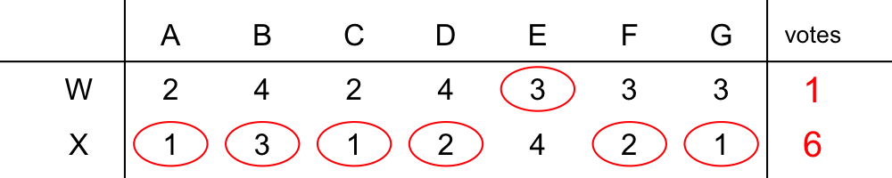

So, X beats W.

Compare candidates W and Y.

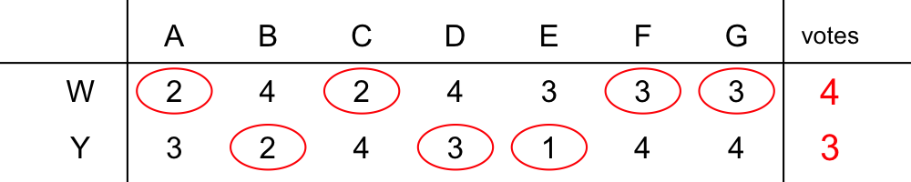

So, W beats Y.

Compare candidates W and Z.

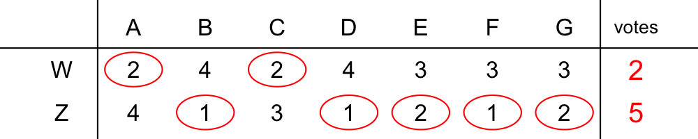

So, Z beats W.

Compare candidates X and Y.

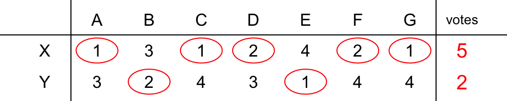

So, X beats Y.

Compare candidates X and Z.

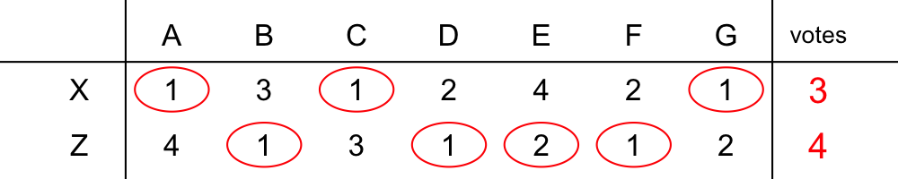

So, Z beats X.

Compare candidates Y and Z.

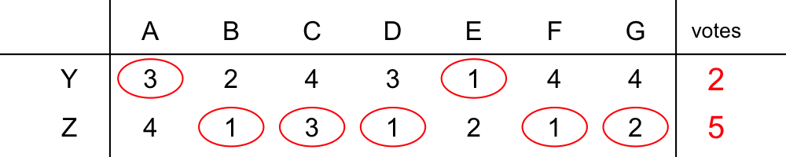

So, Z beats Y.

Organize all this into a winner table.

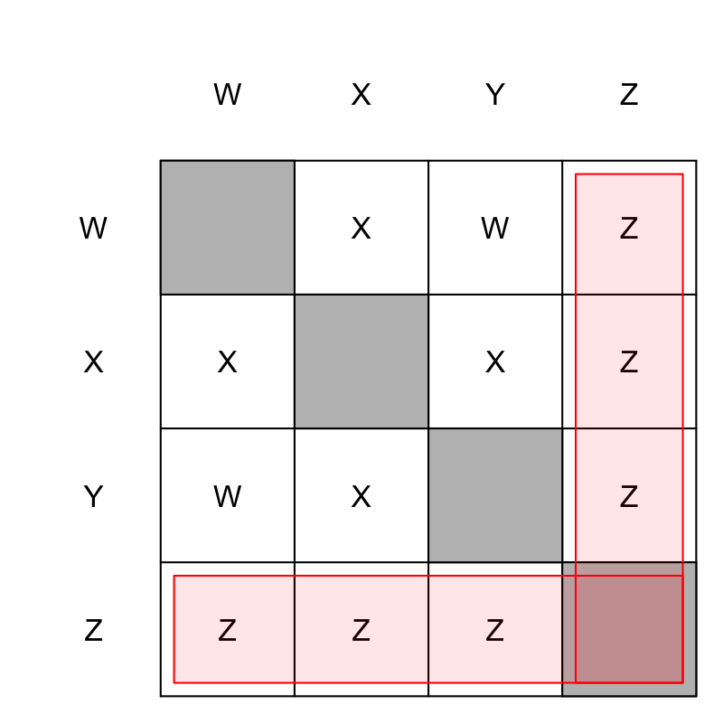

Notice Z wins against all other candidates. Thus Z is the Condorcet winner.

In Adams, Massachusetts, 4 candidates (W through Z) are running in an election with a single winner. There are 7 voters (A through G) who each rank the candidates from 1 to 4, with 1 meaning first choice and 4 meaning last choice. Those rankings are shown below. Each column represents a single voter's ranking.

|  | A | B | C | D | E | F | G |
| --- | --- | --- | --- | --- | --- | --- | --- |
| candidate W | 1 | 4 | 1 | 4 | 1 | 3 | 4 |
| candidate X | 2 | 1 | 2 | 3 | 4 | 2 | 2 |
| candidate Y | 3 | 3 | 4 | 1 | 3 | 4 | 1 |
| candidate Z | 4 | 2 | 3 | 2 | 2 | 1 | 3 |

A [Condorcet winner](https://en.wikipedia.org/wiki/Condorcet_method) would win in a head-to-head election against any other candidate. Who is the Condorcet winner? (Or, possibly, there is none.)

WXYZNo Condorcet winner!

Consider every head-to-head election. With 4 candidates, there will be ${4\choose 2 }= 6$ pairings (see [combinations](https://en.wikipedia.org/wiki/Binomial_coefficient)).

Compare candidates W and X.

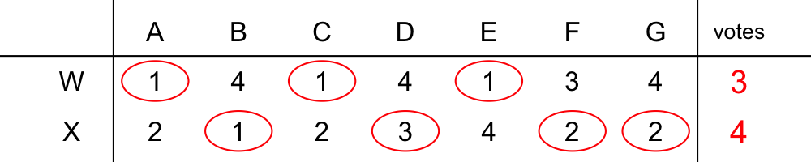

So, X beats W.

Compare candidates W and Y.

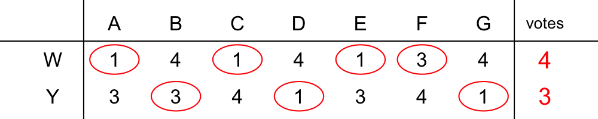

So, W beats Y.

Compare candidates W and Z.

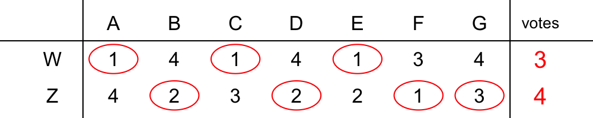

So, Z beats W.

Compare candidates X and Y.

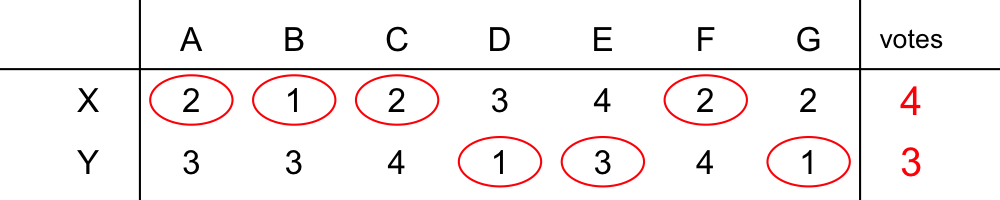

So, X beats Y.

Compare candidates X and Z.

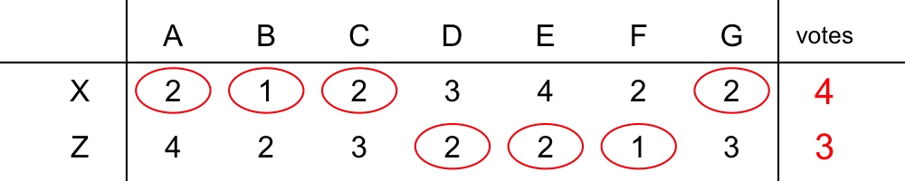

So, X beats Z.

Compare candidates Y and Z.

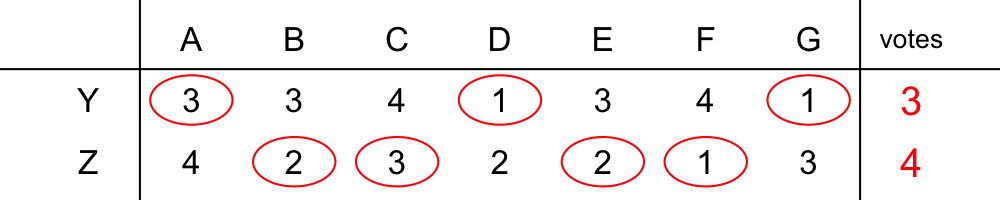

So, Z beats Y.

Organize all this into a winner table.

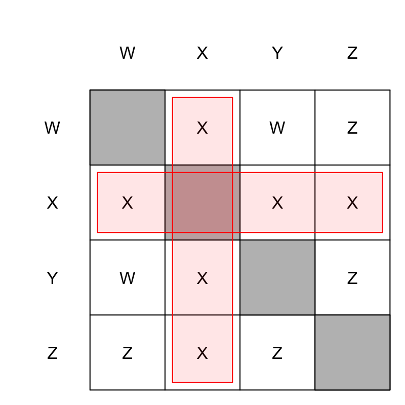

Notice X wins against all other candidates. Thus X is the Condorcet winner.

In Adams, Massachusetts, 4 candidates (W through Z) are running in an election with a single winner. There are 7 voters (A through G) who each rank the candidates from 1 to 4, with 1 meaning first choice and 4 meaning last choice. Those rankings are shown below. Each column represents a single voter's ranking.

|  | A | B | C | D | E | F | G |
| --- | --- | --- | --- | --- | --- | --- | --- |
| candidate W | 3 | 2 | 3 | 2 | 1 | 2 | 2 |
| candidate X | 4 | 4 | 1 | 1 | 4 | 4 | 3 |
| candidate Y | 2 | 1 | 2 | 3 | 3 | 3 | 4 |
| candidate Z | 1 | 3 | 4 | 4 | 2 | 1 | 1 |

A [Condorcet winner](https://en.wikipedia.org/wiki/Condorcet_method) would win in a head-to-head election against any other candidate. Who is the Condorcet winner? (Or, possibly, there is none.)

WXYZNo Condorcet winner!

Consider every head-to-head election. With 4 candidates, there will be ${4\choose 2 }= 6$ pairings (see [combinations](https://en.wikipedia.org/wiki/Binomial_coefficient)).

Compare candidates W and X.

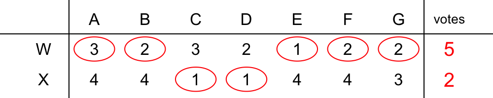

So, W beats X.

Compare candidates W and Y.

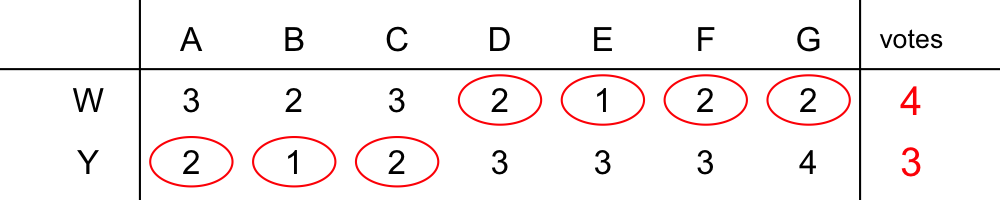

So, W beats Y.

Compare candidates W and Z.

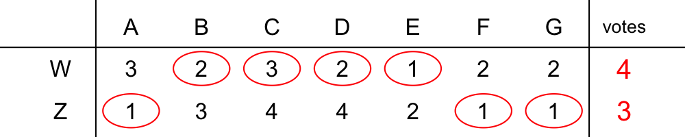

So, W beats Z.

Compare candidates X and Y.

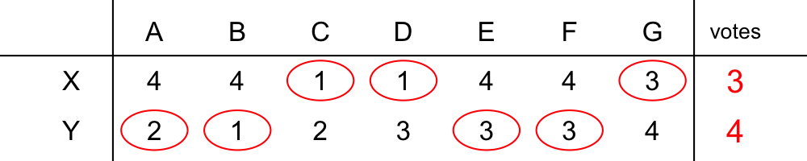

So, Y beats X.